# Ejemplos de Uso

precariedad.mundial

La base de datos homogeneizada de *precariedad.mundial* puede servir de base para el cálculo de un conjunto de indicadores sociolaborales y busca simplificar la comparación entre países. Para procesar la base de datos primero se debe abrir `base_homogenea.RDS` como dataframe.

```r
# Cargar la base de datos homogeneizada
base <- readRDS("~/GitHub/precariedad.mundial/base_homogenea.RDS")
```

A continuación se presentan ejemplos de uso para el procesamiento de los datos y elaboración de gráficos. Parte de estos resultados fueron presentados por nuestro grupo de trabajo [aquí](https://www.unse.edu.ar/trabajoysociedad/38%20GRANA%20ET%20ALT%20La%20calidad%20del%20empleo%20en%20la%20Argentina.pdf) y [aquí](https://doi.org/10.15446/ede.v32n61.100343)).

## Estructura del empleo en el sector privado

El dataframe permite caracterizar la estructura del mercado de trabajo según la información sobre categoría ocupacional en la variable en `CATOCUP` (Cuentapropista, Patrón y Asalariado/a), el tamaño del establecimiento productivo en `TAMA` (Pequeño, Mediano o Grande) y la complejidad en la calificación del puesto en la variable `CALIF` (Alta, Mediana, Baja). Vamos analizar ahora la estructura del mercado de trabajo para la fuerza de trabajo asalariada o cuentapropista del sector privado para todos los países del dataset utilizando estas variables.

Si se quiere analizar al sector privado se debe filtrar por `SECTOR`, que distingue sector público, privado y trabajadoras/es del hogar (SD). Además quitamos del dataframe los casos con datos no válidos en `CALIF` o `TAMA` y generamos etiquetas para los perfiles ocupacionales creados.

```r
base_grupos <- base %>%
  filter(CALIF %in%  c("Alta","Media","Baja")) %>%
  filter(SECTOR == "Priv", !is.na(CALIF), !is.na(TAMA)) %>%
  mutate(grupos = case_when(CATOCUP == "Cuenta propia" ~ paste0("Cuentapropista - ",CALIF),
                            TRUE ~ paste0(TAMA, " - ",CALIF)),
         tamanio.calif = factor(grupos,
                                levels =
                                  c("Cuentapropista - Baja",
                                    "Cuentapropista - Media",
                                    "Cuentapropista - Alta",
                                    "Pequeño - Baja",
                                    "Pequeño - Media",
                                    "Pequeño - Alta",
                                    "Mediano - Baja",
                                    "Mediano - Media",
                                    "Mediano - Alta",
                                    "Grande - Baja",
                                    "Grande - Media",
                                    "Grande - Alta"
                                  )))
```

Luego podemos estimar el peso de cada perfil ocupacional según el entrecruzamiento de las variables `CATOCUP`, `TAMA` y `CALIF`, lo que nos da un total de 12 perfiles ocupacionales. Para calcular indicadores estadísticamente sigfnicativos recordar siempre ponderar por `WEIGHT`.

```r
pesos_perfiles<- base_grupos %>%
  group_by(PAIS,tamanio.calif) %>%
  summarise(casos_pond = sum(WEIGHT,na.rm = T)) %>%
  group_by(PAIS) %>%
  mutate(particip.ocup= casos_pond/sum(casos_pond))
```

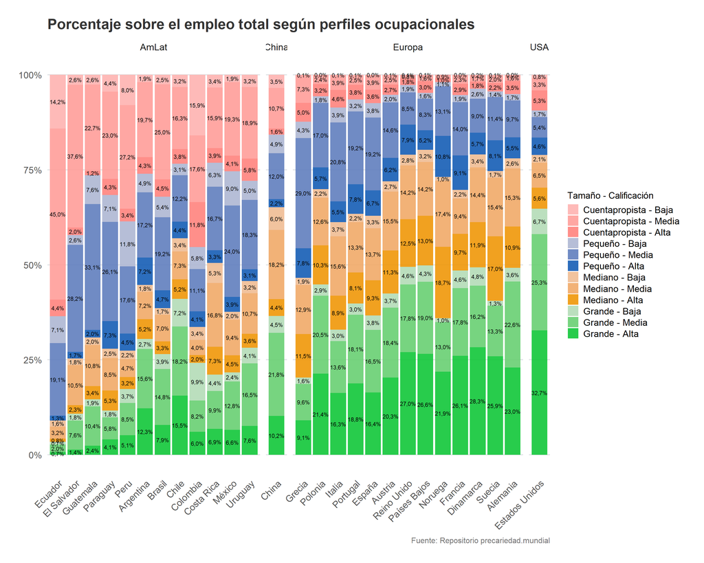

```r
# Define your color palette
azul <- colorspace::diverge_hcl(n = 12, h = c(255, 330), l = c(40, 90))[c(4, 2, 1)]
verde <- colorspace::diverge_hcl(n = 12, h = c(130, 43), c = 100, l = c(70, 90))[c(4, 2, 1)]
naranja <- colorspace::diverge_hcl(n = 12, h = c(130, 43), c = 100, l = c(70, 90))[c(10, 11, 12)]
rojo <- colorspace::diverge_hcl(n = 12, h = 14, c = 100, l = c(70, 90))[c(10, 11, 12)]

paleta <- c(rojo, azul, naranja, verde)

# Load and prepare data
Paises <- read.xlsx("~/GitHub/precariedad.mundial/Fuentes Complementarias/Prod y Salarios.xlsx", sheet = "Paises")
paises_orden <- Paises %>% select(PAIS = nombre.pais, region, Orden, COD.OCDE)

# Plotting
pesos_perfiles %>%
  left_join(paises_orden) %>%
  filter(! COD.OCDE %in% c("BOL", "ROU", "BGR")) %>%
  ggplot(aes(x = reorder(PAIS, Orden), y = particip.ocup, fill = tamanio.calif, group = tamanio.calif,
             label = scales::percent(particip.ocup, decimal.mark = ",", accuracy = 0.1))) +
  geom_col(position = "stack", alpha = 0.9) +  # Add transparency to the bars
  geom_text(position = position_stack(vjust = 0.5), size = 3, color = "black") +  # White text on bars
  labs(
    title = "Porcentaje sobre el empleo total según perfiles ocupacionales",
    caption = "Fuente: Repositorio precariedad.mundial"
  ) +
  theme_minimal(base_size = 18) +  # Use a minimal theme
  theme(
    plot.title = element_text(color = "#333333", size = 22, face = "bold"),
    plot.subtitle = element_text(color = "#555555", size = 16),
    plot.caption = element_text(color = "#777777", size = 12, hjust = 1),
    axis.title = element_blank(),
    axis.text.x = element_text(angle = 45, hjust = 1, color = "#555555"),
    axis.text.y = element_text(color = "#555555"),
    legend.position = "right",
    legend.direction = "vertical",
    legend.title = element_text(size = 14),
    panel.grid.major.y = element_line(color = "#dfe2e5"),
    panel.grid.minor.y = element_blank(),
    panel.grid.major.x = element_blank(),
    panel.grid.minor.x = element_blank(),
    plot.margin = margin(1, 1, 1, 1, "cm")
  ) +
  scale_fill_manual(values = paleta) +
  scale_y_continuous(labels = scales::percent) +
  facet_grid(cols = vars(region), space = "free", scales = "free_x") +
  guides(fill = guide_legend(title = "Tamaño - Calificación"))
```

En el gráfico pueden observase los rasgos típicos de las estructuras del mercado de trabajo latinoamericanas. En los países de América Latina (ubicados a la izquierda del gráfico) es notoriamente mayor el porcentaje del empleo en perfiles de calificación baja y media, dentro de establecimientos de tamaño pequeño. También se nota una mayor importancia del cuentapropismo de baja y media calificación. En contraste, los países de mayor desarrollo productivo (ubicados hacia la derecha del gráfico) presentan una mayor participación del empleo en establecimientos grandes y puestos de alta calificación. En estos países el empleo por cuenta propia tiene un peso mucho menor en la estructura del empleo.

## Expresiones de precariedad laboral para la población asalariada

El dataframe de **precariedad.mundial** tiene información sobre expresiones de precariedad laboral en términos de registración de la relación laboral, falta de aportes a la seguridad social, empleo temporario y empleo part-time involuntario. Para analizar la incidencia de éstas sobre la población asalariada se recomienda filtrar el dataframe para la población asalariada y eliminar casos no válidos para las variables de precariedad.

```r
asalariados <- base_grupos %>%
  filter(CATOCUP == "Asalariado") %>%
  mutate(buen_empleo = ifelse(PRECAPT %in% c(0,NA) &
                                #   PRECAREG%in% c(0,NA) &
                                PRECASEG%in% c(0,NA) &
                                PRECATEMP%in% c(0,NA),"Si","No"))
```

Luego agrupamos los datos por `PAIS` y calculamos la incidencia de cada una de las expresiones de precariedad laboral en la fuerza de trabajo asalariada de cada mercado de trabajo a nivel nacional.

```r
expresiones_pais <- asalariados %>%
  group_by(PAIS) %>%
  summarise(part_time = sum(WEIGHT[PRECAPT==1],na.rm = T)/sum(WEIGHT[PRECAPT %in% 0:1],na.rm = T),
            no_registro = sum(WEIGHT[PRECAREG==1],na.rm = T)/sum(WEIGHT[PRECAREG %in% 0:1],na.rm = T),
            no_seg_social = sum(WEIGHT[PRECASEG==1],na.rm = T)/sum(WEIGHT[PRECASEG %in% 0:1],na.rm = T),
            temporario = sum(WEIGHT[PRECATEMP==1],na.rm = T)/sum(WEIGHT[PRECATEMP %in% 0:1],na.rm = T),
  ) %>%
  pivot_longer(cols = 2:ncol(.),names_to = "expresion",values_to = "valor")
```

Por último graficamos la incidencia de las expresiones de precariedad por pais.

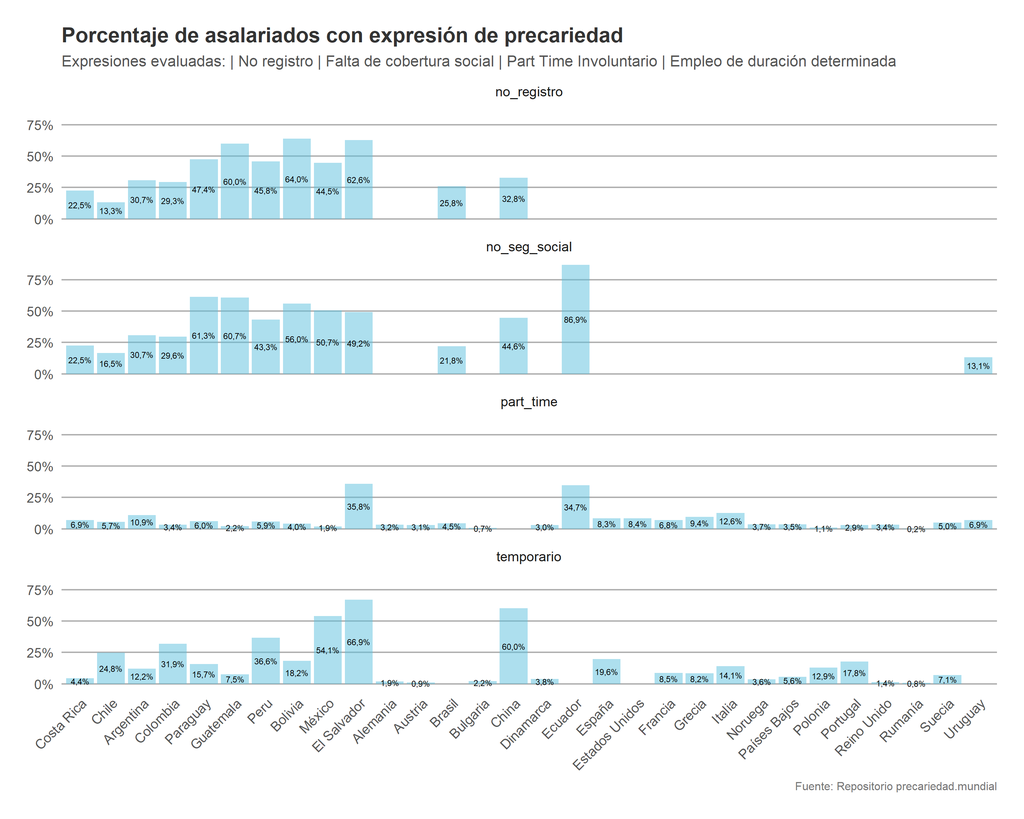

```r
expresiones_pais %>%
  ggplot(aes(x = reorder(PAIS, valor), y = valor,
             label = scales::percent(valor, decimal.mark = ",", accuracy = 0.1))) +
  geom_col(position = "stack", fill = "#5bc0de", alpha = 0.5) +  # Lighter blue and transparency
  geom_text(position = position_stack(vjust = 0.5), size = 3, color = "black") +
  labs(
    title = "Porcentaje de asalariados con expresión de precariedad",
    subtitle = "Expresiones evaluadas: | No registro | Falta de cobertura social | Part Time Involuntario | Empleo de duración determinada",
    caption = "Fuente: Repositorio precariedad.mundial"
  ) +
  theme_minimal(base_size = 18) +  # Clean, minimalist theme with larger text
  theme(
    plot.title = element_text(color = "#333333", size = 22, face = "bold"),  # Dark title
    plot.subtitle = element_text(color = "#555555", size = 16),  # Subtle subtitle color
    plot.caption = element_text(color = "#777777", size = 12, hjust = 1),  # Caption styling
    axis.title = element_blank(),
    axis.text.x = element_text(angle = 45, hjust = 1, color = "#555555"),  # Grey axis labels
    axis.text.y = element_text(color = "#555555"),
    legend.position = "left",
    legend.direction = "vertical",
    legend.title = element_text(size = 14),
    panel.grid.major.y = element_line(color = "#b0b0b0"),  # Light grey grid lines
    panel.grid.minor.y = element_blank(),
    panel.grid.major.x = element_blank(),
    panel.grid.minor.x = element_blank(),
    plot.margin = margin(1, 1, 1, 1, "cm")
  ) +
  facet_wrap(vars(expresion), ncol = 1) +
  scale_y_continuous(labels = scales::percent)
```